# Отчёт по этапу индивидуального проекта №1

Операционные системы

Бызова Мария Олеговна, НПИБД-01-23.

Российский университет дружбы народов, Москва, Россия

## Актуальность

Научному работнику полезно иметь сайт-портфолио про него и его проекты.

## Цель работы

Научиться размещать сайт на Github pages. Выполнить первый этап реализации индвидуального проекта.

## Задание

1. Установить необходимое программное обеспечение.
2. Скачать шаблон темы сайта.
3. Разместить его на хостинге git.
4. Установить параметр для URLs сайта.
5. Разместить заготовку сайта на Github pages.

## Установка необходимого ПО

Скачиваю последнюю версию исполняемого файла hugo для своей операционнной системы (рис. 1).

[figure not shown]

Выбор версии ПО

## Установка необходимого ПО

Распаковываю архив с исполняемым файлом (рис. 2).

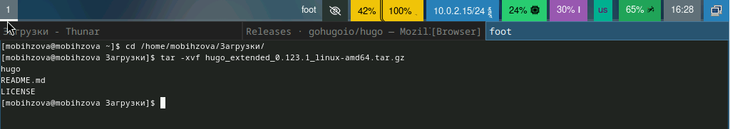

Распаковка архива

## Установка необходимого ПО

Создаю в домашнем каталоге пустую папку bin с помощью утилиты mkdir, переношу в эту папку исполняемый файл hugo (рис. 3).

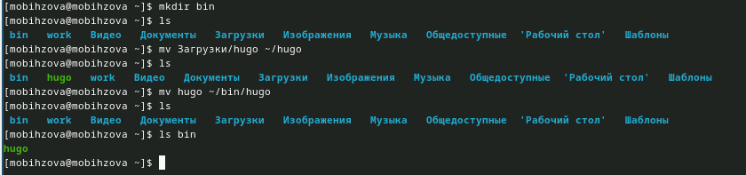

Перемещение файла

## Скачавание шаблона темы сайта

Открываю репозиторий с шаблоном темы сайта (рис. 4).

[figure not shown]

Репозиторий с шаблоном темы сайта

## Скачавание шаблона темы сайта

Создаю свой репозиторий blog на основе репозитория с шаблоном темы сайта (рис. 5).

[figure not shown]

Создание репозитория

## Скачавание шаблона темы сайта

Клонирую созданный репозиторий к себе в локальный репозиторий (рис. 6).

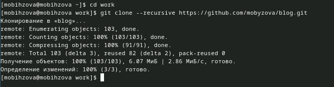

Клонирование репозитория

## Размещение его на хостинге Git

Запускаю исполняемый файл (рис. 7]).

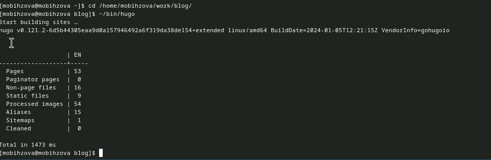

Запуск исполняемого файла

## Размещение его на хостинге Git

Удаляю папку public, которая сейчас нам не понадобится, тем более мы создадим свою (рис. 8).

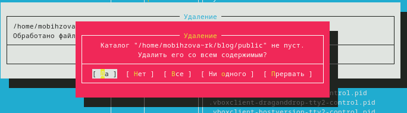

Удаление каталога

## Размещение его на хостинге Git

Снова запускаю исполняемый файл с командой server (рис. 9]).

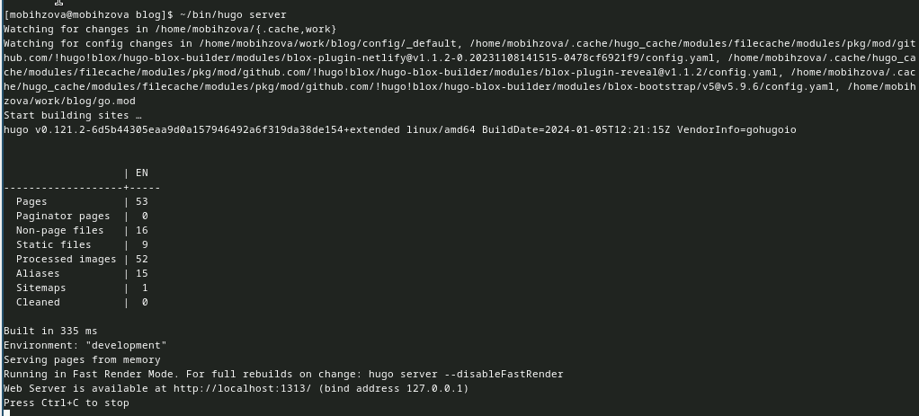

Запуск исполняемого файла

## Размещение его на хостинге Git

Получилась страничка сайта на локальном сервере (рис. 10).

[figure not shown]

Сайт на локальном сервере

## Установка параметров для URLs сайта

Теперь создаю новый пустой репозиторий, чьё имя будет адресом сайта (рис. 11).

[figure not shown]

Создание репозитория

## Установка параметров для URLs сайта

Клонирую созданный репозиторий, чтобы создать локальный репозиторий у себя на компьютере (рис. 12).

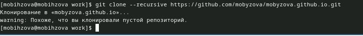

Клонирование репозитория

## Установка параметров для URLs сайта

Создаю главную ветку с именем main (рис. 13).

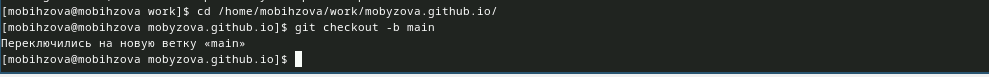

Создание главной ветки

## Установка параметров для URLs сайта

Создаю пустой файл README.md и отправляю изменения на глобальный репозиторий, чтобы его активировать. После этого, перед тем как подключать созданный пустой репозиторий к каталогу public из репозитория blog, нужно отключить в файле gitignore public, чтобы каталоги с таким названием не игнорировались (рис. 14).

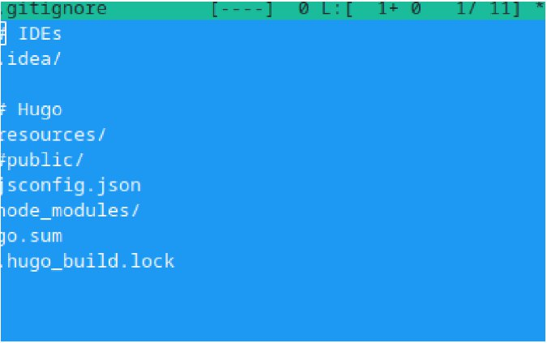

Редактирование файла

## Установка параметров для URLs сайта

Подключаю репозиторий к каталогу public (рис. 15).

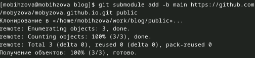

Подключение репозитория к каталогу

## Установка параметров для URLs сайта

Снова выполняю команду исполняемого файла, чтобы заполнить оставйся каталог public (рис. 16]).

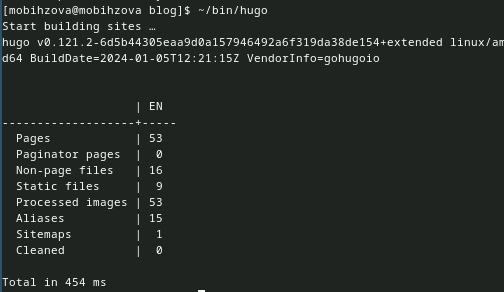

Запуск исполняемого файла

## Размещение заготовки сайта на Github pages

Проверяю, есть ли подключение между public и репозиторием, после чего отправляю изменения на глобальный репозиторий.

## Выводы

В ходе выполнения данной лабораторной работы я научилась размещать сайт на Github pages и выполнила первый этап реализации индивидуального проекта.